# R Recap

## Subsetting

A data frame can be subset using square brackes`[]` placed after the name of the data frame. As a data frame is a two-dimensional object, you need a *row* and *column* index, or vector indices.

*Disclaimer 1*:- later in the course, we will see a slightly-nicer way of subsetting and filtering which will be useful in some circumstances

### Exercise

- Make sure you can understand the behaviour of the following commands

```r
patients[1,2]
patients[2,1]
patients[c(1,2,3),1]
patients[c(1,2,3),c(1,2,3)]
```

*Note that the data frame is not altered* we are just seeing what a subset of the data looks like and not changing the underlying data. If we wanted to do this, we would need to create a new variale.

```r
patients
```

```
##    ID   Name     Race    Sex Smokes Height      Birth        State  Pet
## 1  01  Britt    White   Male   TRUE     71 1972-10-28    Wisconsin  Cat
## 2  02 Martin    White   Male  FALSE     68 1973-06-11     Colorado None
## 3  03  Young    White Female  FALSE     67 1972-02-10 Pennsylvania  Dog
## 4  04   Deon Hispanic   Male  FALSE     77 1972-11-12      Georgia  Cat
## 5  05   Juan Hispanic   Male   TRUE     65 1972-09-06     New York  Dog
## 6  06  Devon    White   Male   TRUE     71 1972-11-05     Missouri  Dog
## 7  07   Adam    Black Female  FALSE     68 1973-03-01     New York  Dog
## 8  08   Cary    White   Male  FALSE     66 1972-01-08      Indiana None
## 9  09   Yong    White Female  FALSE     74 1972-01-19         Ohio  Cat
## 10 10  Clyde    White Female  FALSE     67 1972-03-16 Pennsylvania  Dog
##    Grade_Level  Died      Count       Date
## 1            3  TRUE  2.0429659 2015-09-23
## 2            2 FALSE -0.3968310 2015-11-23
## 3            3  TRUE  0.9995400 2015-12-23
## 4            1  TRUE -0.3263563 2016-01-23
## 5            3 FALSE  0.1008862 2016-02-23
## 6            3 FALSE  2.4956672 2016-02-23
## 7            3  TRUE -0.9369304 2016-04-23
## 8            3  TRUE -1.0275402 2016-05-23
## 9            1 FALSE  0.6261153 2016-06-23
## 10           2  TRUE  0.4947157 2016-06-23
```

Should we wish to see all rows, or all columns, we can neglect either the row or column index

### Exercise

- Make sure you can understand the behaviour of the following commands

```r
patients[1,]
patients[,1]
patients[,c(1,2)]
```

### Exercise

- How can we view all information about the first six patients?
- HINT `head` is commonly-used to give a snapshot of a data frame. Otherwise, you can use the `[row,column]` notation.

```
##   ID   Name     Race    Sex Smokes Height      Birth        State  Pet
## 1 01  Britt    White   Male   TRUE     71 1972-10-28    Wisconsin  Cat
## 2 02 Martin    White   Male  FALSE     68 1973-06-11     Colorado None
## 3 03  Young    White Female  FALSE     67 1972-02-10 Pennsylvania  Dog
## 4 04   Deon Hispanic   Male  FALSE     77 1972-11-12      Georgia  Cat
## 5 05   Juan Hispanic   Male   TRUE     65 1972-09-06     New York  Dog
## 6 06  Devon    White   Male   TRUE     71 1972-11-05     Missouri  Dog
##   Grade_Level  Died      Count       Date
## 1           3  TRUE  2.0429659 2015-09-23
## 2           2 FALSE -0.3968310 2015-11-23
## 3           3  TRUE  0.9995400 2015-12-23
## 4           1  TRUE -0.3263563 2016-01-23
## 5           3 FALSE  0.1008862 2016-02-23
## 6           3 FALSE  2.4956672 2016-02-23
```

Rather than selecting rows based on their *numeric* index (as in the previous example) we can use what we call a *logical test*. This is a test that gives either a `TRUE` or `FALSE` result. When applied to subsetting, only rows with a `TRUE` result get returned.

For example we could compare the `Count` variable to zero. The result is a *vector* of `TRUE` or `FALSE`; one for each row in the data frame

```r
patients$Count < 0
```

```
##  [1] FALSE  TRUE FALSE  TRUE FALSE FALSE  TRUE  TRUE FALSE FALSE
```

This R code can be put inside the square brackets.

```r
patients[patients$Count<0, ]
```

```
##   ID   Name     Race    Sex Smokes Height      Birth    State  Pet
## 2 02 Martin    White   Male  FALSE     68 1973-06-11 Colorado None
## 4 04   Deon Hispanic   Male  FALSE     77 1972-11-12  Georgia  Cat
## 7 07   Adam    Black Female  FALSE     68 1973-03-01 New York  Dog
## 8 08   Cary    White   Male  FALSE     66 1972-01-08  Indiana None
##   Grade_Level  Died      Count       Date
## 2           2 FALSE -0.3968310 2015-11-23
## 4           1  TRUE -0.3263563 2016-01-23
## 7           3  TRUE -0.9369304 2016-04-23
## 8           3  TRUE -1.0275402 2016-05-23
```

If we wanted to know about the patients that had died, we could do;

```r
deceased <- patients[patients$Died == TRUE,]
deceased
```

```
##    ID  Name     Race    Sex Smokes Height      Birth        State  Pet
## 1  01 Britt    White   Male   TRUE     71 1972-10-28    Wisconsin  Cat
## 3  03 Young    White Female  FALSE     67 1972-02-10 Pennsylvania  Dog
## 4  04  Deon Hispanic   Male  FALSE     77 1972-11-12      Georgia  Cat
## 7  07  Adam    Black Female  FALSE     68 1973-03-01     New York  Dog
## 8  08  Cary    White   Male  FALSE     66 1972-01-08      Indiana None
## 10 10 Clyde    White Female  FALSE     67 1972-03-16 Pennsylvania  Dog
##    Grade_Level Died      Count       Date
## 1            3 TRUE  2.0429659 2015-09-23
## 3            3 TRUE  0.9995400 2015-12-23
## 4            1 TRUE -0.3263563 2016-01-23
## 7            3 TRUE -0.9369304 2016-04-23
## 8            3 TRUE -1.0275402 2016-05-23
## 10           2 TRUE  0.4947157 2016-06-23
```

In fact, this is equivalent

```r
deceased <- patients[patients$Died,]
```

The test of equality `==` also works for text

```r
patients[patients$Race == "White",]
```

```
##    ID   Name  Race    Sex Smokes Height      Birth        State  Pet
## 1  01  Britt White   Male   TRUE     71 1972-10-28    Wisconsin  Cat
## 2  02 Martin White   Male  FALSE     68 1973-06-11     Colorado None
## 3  03  Young White Female  FALSE     67 1972-02-10 Pennsylvania  Dog
## 6  06  Devon White   Male   TRUE     71 1972-11-05     Missouri  Dog
## 8  08   Cary White   Male  FALSE     66 1972-01-08      Indiana None
## 9  09   Yong White Female  FALSE     74 1972-01-19         Ohio  Cat
## 10 10  Clyde White Female  FALSE     67 1972-03-16 Pennsylvania  Dog
##    Grade_Level  Died      Count       Date
## 1            3  TRUE  2.0429659 2015-09-23
## 2            2 FALSE -0.3968310 2015-11-23
## 3            3  TRUE  0.9995400 2015-12-23
## 6            3 FALSE  2.4956672 2016-02-23
## 8            3  TRUE -1.0275402 2016-05-23
## 9            1 FALSE  0.6261153 2016-06-23
## 10           2  TRUE  0.4947157 2016-06-23
```

### Exercise

- Can you create a data frame of dog owners?

```
##    ID  Name     Race    Sex Smokes Height      Birth        State Pet
## 3  03 Young    White Female  FALSE     67 1972-02-10 Pennsylvania Dog
## 5  05  Juan Hispanic   Male   TRUE     65 1972-09-06     New York Dog
## 6  06 Devon    White   Male   TRUE     71 1972-11-05     Missouri Dog
## 7  07  Adam    Black Female  FALSE     68 1973-03-01     New York Dog
## 10 10 Clyde    White Female  FALSE     67 1972-03-16 Pennsylvania Dog
##    Grade_Level  Died      Count       Date
## 3            3  TRUE  0.9995400 2015-12-23
## 5            3 FALSE  0.1008862 2016-02-23
## 6            3 FALSE  2.4956672 2016-02-23
## 7            3  TRUE -0.9369304 2016-04-23
## 10           2  TRUE  0.4947157 2016-06-23
```

There are a couple of ways of testing for more than one text value. The first uses an *or* `|` statement. i.e. testing if the value of `Pet` is `Dog` *or* the value is `Cat`.

The `%in%` function is a convenient function for testing which items in a vector correspond to a defined set of values.

```r
patients[patients$Pet == "Dog" | patients$Pet == "Cat",]
```

```
##    ID  Name     Race    Sex Smokes Height      Birth        State Pet
## 1  01 Britt    White   Male   TRUE     71 1972-10-28    Wisconsin Cat
## 3  03 Young    White Female  FALSE     67 1972-02-10 Pennsylvania Dog
## 4  04  Deon Hispanic   Male  FALSE     77 1972-11-12      Georgia Cat
## 5  05  Juan Hispanic   Male   TRUE     65 1972-09-06     New York Dog
## 6  06 Devon    White   Male   TRUE     71 1972-11-05     Missouri Dog
## 7  07  Adam    Black Female  FALSE     68 1973-03-01     New York Dog
## 9  09  Yong    White Female  FALSE     74 1972-01-19         Ohio Cat
## 10 10 Clyde    White Female  FALSE     67 1972-03-16 Pennsylvania Dog
##    Grade_Level  Died      Count       Date
## 1            3  TRUE  2.0429659 2015-09-23
## 3            3  TRUE  0.9995400 2015-12-23
## 4            1  TRUE -0.3263563 2016-01-23
## 5            3 FALSE  0.1008862 2016-02-23
## 6            3 FALSE  2.4956672 2016-02-23
## 7            3  TRUE -0.9369304 2016-04-23
## 9            1 FALSE  0.6261153 2016-06-23
## 10           2  TRUE  0.4947157 2016-06-23
```

```r
patients[patients$Pet %in% c("Dog","Cat"),]
```

```
##    ID  Name     Race    Sex Smokes Height      Birth        State Pet
## 1  01 Britt    White   Male   TRUE     71 1972-10-28    Wisconsin Cat
## 3  03 Young    White Female  FALSE     67 1972-02-10 Pennsylvania Dog
## 4  04  Deon Hispanic   Male  FALSE     77 1972-11-12      Georgia Cat
## 5  05  Juan Hispanic   Male   TRUE     65 1972-09-06     New York Dog
## 6  06 Devon    White   Male   TRUE     71 1972-11-05     Missouri Dog
## 7  07  Adam    Black Female  FALSE     68 1973-03-01     New York Dog
## 9  09  Yong    White Female  FALSE     74 1972-01-19         Ohio Cat
## 10 10 Clyde    White Female  FALSE     67 1972-03-16 Pennsylvania Dog
##    Grade_Level  Died      Count       Date
## 1            3  TRUE  2.0429659 2015-09-23
## 3            3  TRUE  0.9995400 2015-12-23
## 4            1  TRUE -0.3263563 2016-01-23
## 5            3 FALSE  0.1008862 2016-02-23
## 6            3 FALSE  2.4956672 2016-02-23
## 7            3  TRUE -0.9369304 2016-04-23
## 9            1 FALSE  0.6261153 2016-06-23
## 10           2  TRUE  0.4947157 2016-06-23
```

Similar to *or*, we can require that both tests are `TRUE` by using an *and* `&` operation. e.g. to look for white males.

```r
patients[patients$Race == "White" & patients$Sex =="Male",]
```

```
##   ID   Name  Race  Sex Smokes Height      Birth     State  Pet Grade_Level
## 1 01  Britt White Male   TRUE     71 1972-10-28 Wisconsin  Cat           3
## 2 02 Martin White Male  FALSE     68 1973-06-11  Colorado None           2
## 6 06  Devon White Male   TRUE     71 1972-11-05  Missouri  Dog           3
## 8 08   Cary White Male  FALSE     66 1972-01-08   Indiana None           3
##    Died     Count       Date
## 1  TRUE  2.042966 2015-09-23
## 2 FALSE -0.396831 2015-11-23
## 6 FALSE  2.495667 2016-02-23
## 8  TRUE -1.027540 2016-05-23
```

### Exercise

- Can you create a data frame of deceased patients with a ‘count’ < 0

```
##   ID Name     Race    Sex Smokes Height      Birth    State  Pet
## 4 04 Deon Hispanic   Male  FALSE     77 1972-11-12  Georgia  Cat
## 7 07 Adam    Black Female  FALSE     68 1973-03-01 New York  Dog
## 8 08 Cary    White   Male  FALSE     66 1972-01-08  Indiana None
##   Grade_Level Died      Count       Date
## 4           1 TRUE -0.3263563 2016-01-23
## 7           3 TRUE -0.9369304 2016-04-23
## 8           3 TRUE -1.0275402 2016-05-23
```

## Ordering and sorting

A vector can be returned in sorted form using the `sort` function.

```r
sort(peeps)
```

```
##  [1] "Adam"   "Britt"  "Cary"   "Clyde"  "Deon"   "Devon"  "Juan"
##  [8] "Martin" "Yong"   "Young"
```

```r
sort(patients$Count,decreasing = TRUE)
```

```
##  [1]  2.4956672  2.0429659  0.9995400  0.6261153  0.4947157  0.1008862
##  [7] -0.3263563 -0.3968310 -0.9369304 -1.0275402
```

However, if we want to sort an entire data frame a different approach is needed. The trick is to use `order`. Rather than giving a sorted set of *values*, it will give sorted *indices*.

```r
patients[order(patients$Count),]
```

```
##    ID   Name     Race    Sex Smokes Height      Birth        State  Pet
## 8  08   Cary    White   Male  FALSE     66 1972-01-08      Indiana None
## 7  07   Adam    Black Female  FALSE     68 1973-03-01     New York  Dog
## 2  02 Martin    White   Male  FALSE     68 1973-06-11     Colorado None
## 4  04   Deon Hispanic   Male  FALSE     77 1972-11-12      Georgia  Cat
## 5  05   Juan Hispanic   Male   TRUE     65 1972-09-06     New York  Dog
## 10 10  Clyde    White Female  FALSE     67 1972-03-16 Pennsylvania  Dog
## 9  09   Yong    White Female  FALSE     74 1972-01-19         Ohio  Cat
## 3  03  Young    White Female  FALSE     67 1972-02-10 Pennsylvania  Dog
## 1  01  Britt    White   Male   TRUE     71 1972-10-28    Wisconsin  Cat
## 6  06  Devon    White   Male   TRUE     71 1972-11-05     Missouri  Dog
##    Grade_Level  Died      Count       Date
## 8            3  TRUE -1.0275402 2016-05-23
## 7            3  TRUE -0.9369304 2016-04-23
## 2            2 FALSE -0.3968310 2015-11-23
## 4            1  TRUE -0.3263563 2016-01-23
## 5            3 FALSE  0.1008862 2016-02-23
## 10           2  TRUE  0.4947157 2016-06-23
## 9            1 FALSE  0.6261153 2016-06-23
## 3            3  TRUE  0.9995400 2015-12-23
## 1            3  TRUE  2.0429659 2015-09-23
## 6            3 FALSE  2.4956672 2016-02-23
```

```r
patients[order(patients$Sex),]
```

```
##    ID   Name     Race    Sex Smokes Height      Birth        State  Pet
## 1  01  Britt    White   Male   TRUE     71 1972-10-28    Wisconsin  Cat
## 2  02 Martin    White   Male  FALSE     68 1973-06-11     Colorado None
## 4  04   Deon Hispanic   Male  FALSE     77 1972-11-12      Georgia  Cat
## 5  05   Juan Hispanic   Male   TRUE     65 1972-09-06     New York  Dog
## 6  06  Devon    White   Male   TRUE     71 1972-11-05     Missouri  Dog
## 8  08   Cary    White   Male  FALSE     66 1972-01-08      Indiana None
## 3  03  Young    White Female  FALSE     67 1972-02-10 Pennsylvania  Dog
## 7  07   Adam    Black Female  FALSE     68 1973-03-01     New York  Dog
## 9  09   Yong    White Female  FALSE     74 1972-01-19         Ohio  Cat
## 10 10  Clyde    White Female  FALSE     67 1972-03-16 Pennsylvania  Dog
##    Grade_Level  Died      Count       Date
## 1            3  TRUE  2.0429659 2015-09-23
## 2            2 FALSE -0.3968310 2015-11-23
## 4            1  TRUE -0.3263563 2016-01-23
## 5            3 FALSE  0.1008862 2016-02-23
## 6            3 FALSE  2.4956672 2016-02-23
## 8            3  TRUE -1.0275402 2016-05-23
## 3            3  TRUE  0.9995400 2015-12-23
## 7            3  TRUE -0.9369304 2016-04-23
## 9            1 FALSE  0.6261153 2016-06-23
## 10           2  TRUE  0.4947157 2016-06-23
```

A final point on data frames is that we can export them out of R once we have done our data processing.

```r
countOrder <- patients[order(patients$Count),]
write.csv(countOrder, file="patientsOrderedByCount.csv")
```

## Simple plotting

All your favourite types of plot can be created in R

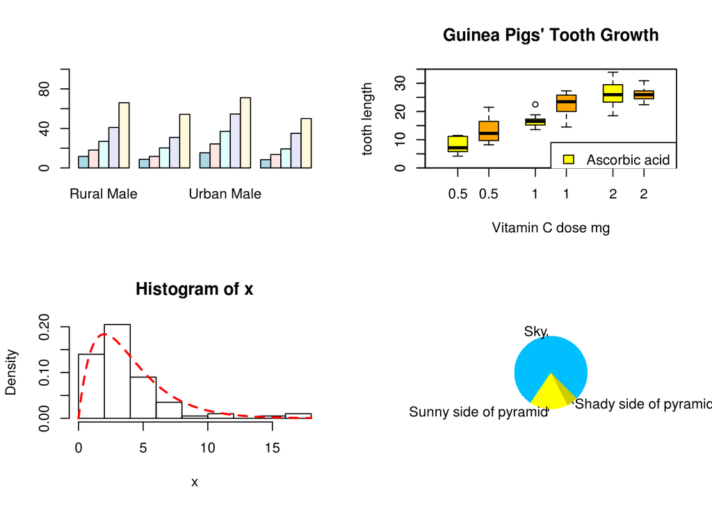

## Plotting

- Simple plots are supported in the *base* distribution of R (what you get automatically when you download R).
  - `boxplot`, `hist`, `barplot`,… all of which are extensions of the basic `plot` function
- Many different customisations are possible
  - colour, overlay points / text, legends, multi-panel figures
- We will show how some of these plots can be used to inform us about the quality of NGS data, and to visualise our results.
- References..
  - [Introductory R course](http://cambiotraining.github.io/r-intro/)
  - [Quick-R](http://www.statmethods.net/graphs/index.html)

*Disclaimer 2*:- later in the course, we will see a slightly-nicer way of plotting

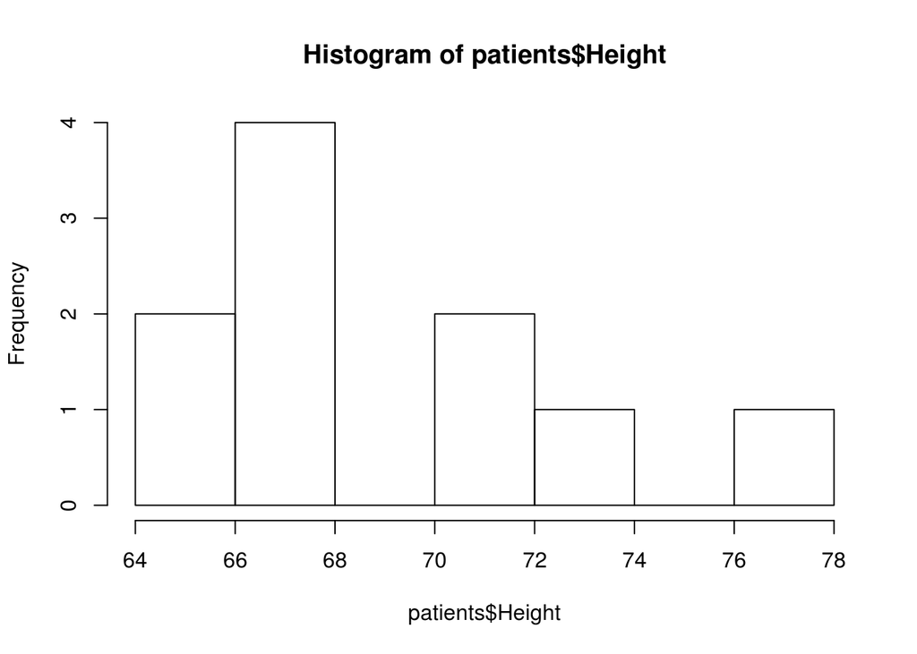

```r
hist(patients$Height)
```

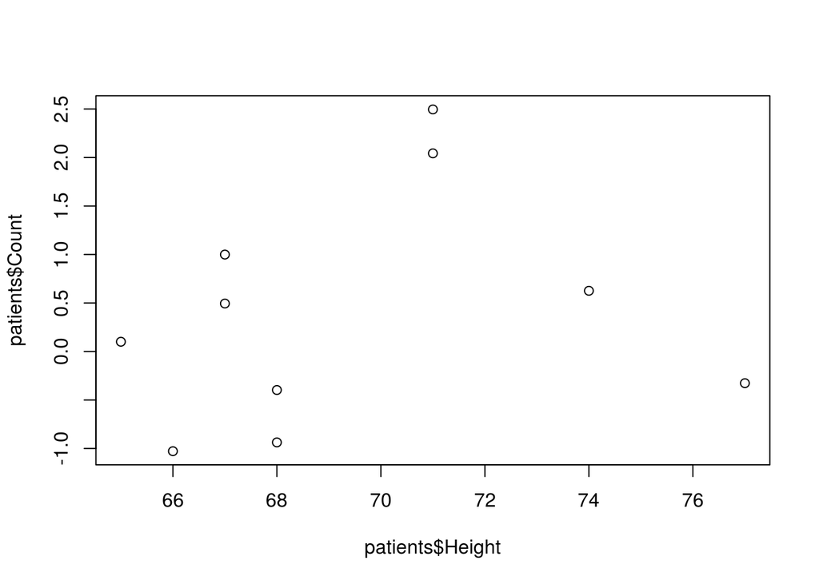

```r
plot(patients$Height,patients$Count)
```

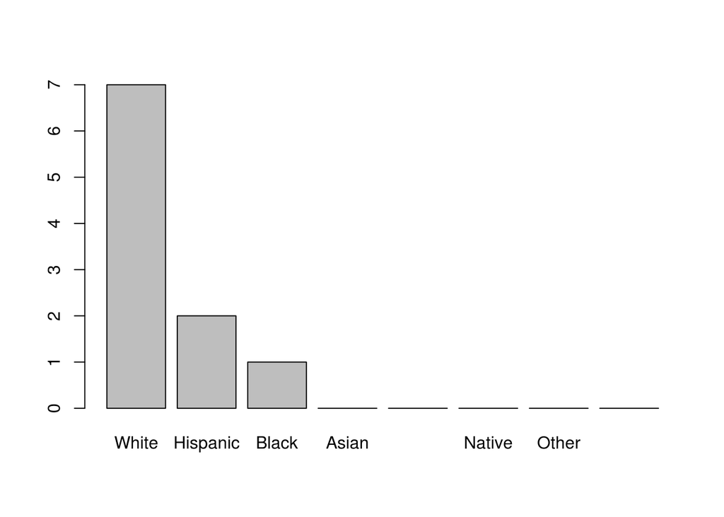

```r
barplot(table(patients$Race))
```

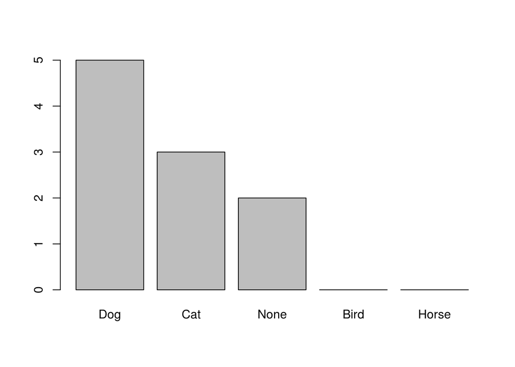

```r
barplot(table(patients$Pet))
```

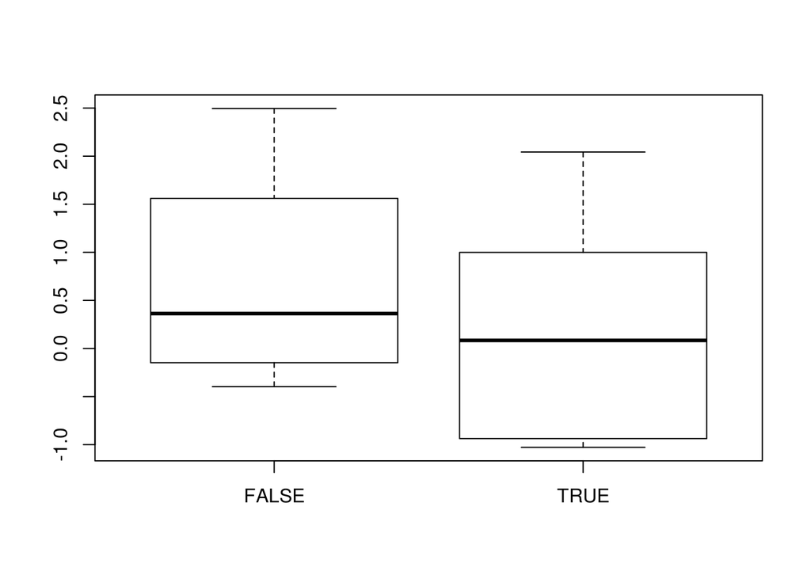

```r
boxplot(patients$Count ~ patients$Died)
```

*Lots* of customisations are possible to enhance the appaerance of our plots; colour, labels, axes, legends

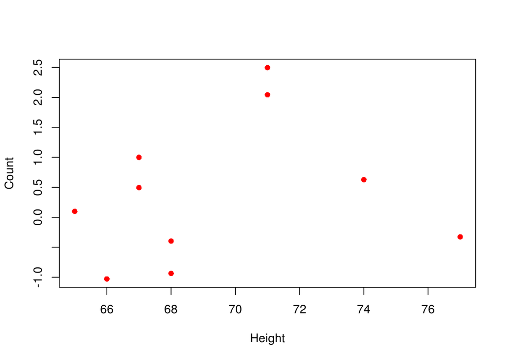

```r
plot(patients$Height,patients$Count,pch=16,
     col="red",xlab="Height",
     ylab="Count")
```

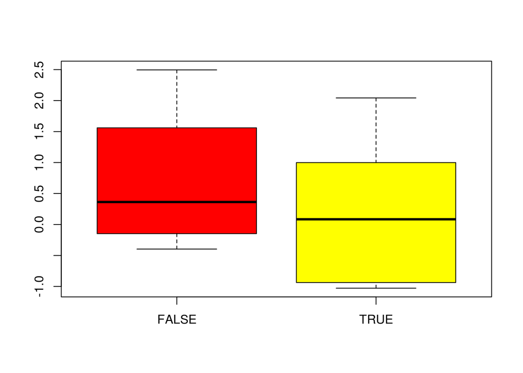

```r
boxplot(patients$Count ~ patients$Died,col=c("red","yellow"))
```

Plots can be exported by the *Plots* tab in RStudio, or by calling the `pdf` or `png` functions which will write the plot to a file

```r
png("myLittlePlot.png")
barplot(table(patients$Pet))
dev.off()
```